# CMSC320 Final Project

Andrew Cachiaras

May 14, 2018

# Minnesota Vikings Defense Final Tutorial

## Introduction

This is a tutorial which will teach some introductory data science principles.

In this tutorial, we will be analyzing NFL statistics. In particular, we will look at the defense of the Minnesota Vikings over time.

These are the libraries that we will be using for this tutorial. Make sure to install them from CRAN and implement them.

```r
library(tidyverse)
```

```r
library(ggplot2)
```

# Getting Started

We will be using a dataset of NFL statistics from Kaggle. It can be found here: https://www.kaggle.com/kendallgillies/nflstatistics/version/1#. This is a series of CSV (comma-seperated values) files. We won’t be using all of the files in the linked download, only two different tables. Now you need to load the Quarterback Game Logs and the Runningback Game Logs tables into R using the read_csv function.

```r
url <- "https://raw.githubusercontent.com/ajcachiaras/ajcachiaras.github.io/master/Game_Logs_Quarterback.csv"
url2 <- "https://raw.githubusercontent.com/ajcachiaras/ajcachiaras.github.io/master/Game_Logs_Runningback.csv"
qb_stats_tab <- read_csv(url)
rb_stats_tab <- read_csv(url2)
#print first 6 rows
qb_stats_tab %>% head()
```

```
## # A tibble: 6 x 29
##   `Player Id` Name  Position  Year Season  Week `Game Date` `Home or Away`
##   <chr>       <chr> <chr>    <int> <chr>  <int> <chr>       <chr>
## 1 jaredzabra~ Zabr~ <NA>      2007 Prese~     1 08/11       Home
## 2 jaredzabra~ Zabr~ <NA>      2007 Prese~     2 08/18       Away
## 3 jaredzabra~ Zabr~ <NA>      2007 Prese~     3 08/25       Home
## 4 jaredzabra~ Zabr~ <NA>      2007 Prese~     4 08/30       Away
## 5 billdemory~ Demo~ <NA>      1974 Regul~     1 09/15       Away
## 6 billdemory~ Demo~ <NA>      1974 Regul~     2 09/22       Away
## # ... with 21 more variables: Opponent <chr>, Outcome <chr>, Score <chr>,
## #   `Games Played` <int>, `Games Started` <chr>, `Passes Completed` <chr>,
## #   `Passes Attempted` <chr>, `Completion Percentage` <chr>, `Passing
## #   Yards` <chr>, `Passing Yards Per Attempt` <chr>, `TD Passes` <chr>,
## #   Ints <chr>, Sacks <chr>, `Sacked Yards Lost` <chr>, `Passer
## #   Rating` <dbl>, `Rushing Attempts` <chr>, `Rushing Yards` <chr>, `Yards
## #   Per Carry` <chr>, `Rushing TDs` <chr>, Fumbles <chr>, `Fumbles
## #   Lost` <chr>
```

```r
rb_stats_tab %>% head()
```

```
## # A tibble: 6 x 25
##   `Player Id` Name  Position  Year Season  Week `Game Date` `Home or Away`
##   <chr>       <chr> <chr>    <int> <chr>  <int> <chr>       <chr>
## 1 bobbyfowle~ Fowl~ <NA>      1985 Regul~     7 10/20       Away
## 2 bobbyfowle~ Fowl~ <NA>      1985 Regul~     8 10/27       Home
## 3 bobbyfowle~ Fowl~ <NA>      1985 Regul~     9 11/03       Away
## 4 bobbyfowle~ Fowl~ <NA>      1985 Regul~    10 11/10       Home
## 5 bobbyfowle~ Fowl~ <NA>      1985 Regul~    11 11/17       Away
## 6 bobbyfowle~ Fowl~ <NA>      1985 Regul~    12 11/24       Away
## # ... with 17 more variables: Opponent <chr>, Outcome <chr>, Score <chr>,
## #   `Games Played` <int>, `Games Started` <chr>, `Rushing Attempts` <chr>,
## #   `Rushing Yards` <chr>, `Yards Per Carry` <chr>, `Longest Rushing
## #   Run` <chr>, `Rushing TDs` <chr>, Receptions <chr>, `Receiving
## #   Yards` <chr>, `Yards Per Reception` <chr>, `Longest Reception` <chr>,
## #   `Receiving TDs` <chr>, Fumbles <chr>, `Fumbles Lost` <chr>
```

# Wrangling

We also notice that some of the columns in our dataset are labeled as character type, which won’t allow us to perform numeric operations on them. We use the transform function to change the columns we will use into numeric data types.

The last thing that we will do in our wrangling of the data is make a new column (using the mutate function) that keeps track of the average yardage per year. Make sure to use the group_by funtion with `Year` as a parameter first, otherwise the new column will be the average of one point.

```r
filtered_qb_df <- qb_stats_tab %>%
  filter(`Year` >= 1950) %>%
  filter(`Passes Attempted` >= 1) %>%
  filter(`Opponent` == "MIN") %>%
  transform(`Passing Yards` = as.numeric(`Passing Yards`)) %>%
  group_by(`Year`) %>%
  mutate(avg_pass_yds = mean(`Passing.Yards`))
filtered_qb_df %>% head()
```

```
## # A tibble: 6 x 30
## # Groups:   Year [6]
##   Player.Id    Name    Position  Year Season   Week Game.Date Home.or.Away
##   <chr>        <chr>   <chr>    <int> <chr>   <int> <chr>     <chr>
## 1 rudycarpent~ Carpen~ <NA>      2009 Presea~     4 09/04     Away
## 2 jameillshow~ Shower~ QB        2015 Presea~     3 08/29     Home
## 3 frantarkent~ Tarken~ <NA>      1971 Regula~     7 10/31     Home
## 4 darylelamon~ Lamoni~ <NA>      1973 Regula~     1 09/16     Away
## 5 davidgarrar~ Garrar~ <NA>      2008 Regula~    12 11/23     Home
## 6 rustylisch/~ Lisch,~ <NA>      1984 Regula~    13 11/25     Away
## # ... with 22 more variables: Opponent <chr>, Outcome <chr>, Score <chr>,
## #   Games.Played <int>, Games.Started <chr>, Passes.Completed <chr>,
## #   Passes.Attempted <chr>, Completion.Percentage <chr>,
## #   Passing.Yards <dbl>, Passing.Yards.Per.Attempt <chr>, TD.Passes <chr>,
## #   Ints <chr>, Sacks <chr>, Sacked.Yards.Lost <chr>, Passer.Rating <dbl>,
## #   Rushing.Attempts <chr>, Rushing.Yards <chr>, Yards.Per.Carry <chr>,
## #   Rushing.TDs <chr>, Fumbles <chr>, Fumbles.Lost <chr>,
## #   avg_pass_yds <dbl>
```

```r
filtered_rb_df <- rb_stats_tab %>%
  filter(`Year` >= 1950) %>%
  filter(`Rushing Attempts` >= 1) %>%
  filter(`Opponent` == "MIN") %>%
  transform(`Rushing Yards` = as.numeric(`Rushing Yards`)) %>%
  group_by(`Year`) %>%
  mutate(avg_rush_yds = mean(`Rushing.Yards`))
filtered_rb_df %>% head()
```

```
## # A tibble: 6 x 26
## # Groups:   Year [4]
##   Player.Id    Name   Position  Year Season    Week Game.Date Home.or.Away
##   <chr>        <chr>  <chr>    <int> <chr>    <int> <chr>     <chr>
## 1 tonydavis/2~ Davis~ <NA>      1980 Regular~    14 12/07     Home
## 2 garryjames/~ James~ <NA>      1988 Regular~    10 11/06     Away
## 3 garryjames/~ James~ <NA>      1988 Regular~    13 11/24     Home
## 4 garryjames/~ James~ <NA>      1987 Regular~    14 12/20     Home
## 5 garryjames/~ James~ <NA>      1986 Regular~     1 09/07     Away
## 6 garryjames/~ James~ <NA>      1986 Regular~    10 11/09     Home
## # ... with 18 more variables: Opponent <chr>, Outcome <chr>, Score <chr>,
## #   Games.Played <int>, Games.Started <chr>, Rushing.Attempts <chr>,
## #   Rushing.Yards <dbl>, Yards.Per.Carry <chr>, Longest.Rushing.Run <chr>,
## #   Rushing.TDs <chr>, Receptions <chr>, Receiving.Yards <chr>,
## #   Yards.Per.Reception <chr>, Longest.Reception <chr>,
## #   Receiving.TDs <chr>, Fumbles <chr>, Fumbles.Lost <chr>,
## #   avg_rush_yds <dbl>
```

# Visualizing

Let’s look at how the Vikings’ pass defense has affected their win rate. In order to do this we want to plot their Passing yards, with a point for each game, with another variable to indicate the outcome.

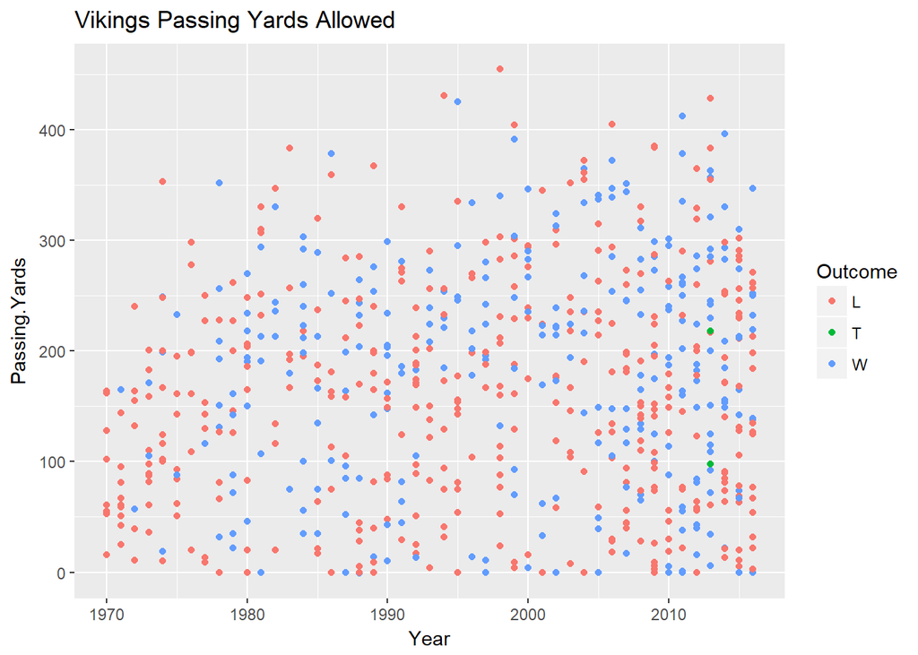

```r
filtered_qb_df %>%
  ggplot(aes(x=`Year`, y=`Passing.Yards`)) +
  geom_point(mapping=aes(color=`Outcome`)) +
  labs(title = "Vikings Passing Yards Allowed")
```

It is hard to determine any real trend from this data. It would seem that when the Vikings allow less passing yardage, they win. However, there is no obvious pattern to back this up.

Lets do the same thing for rushing yardage:

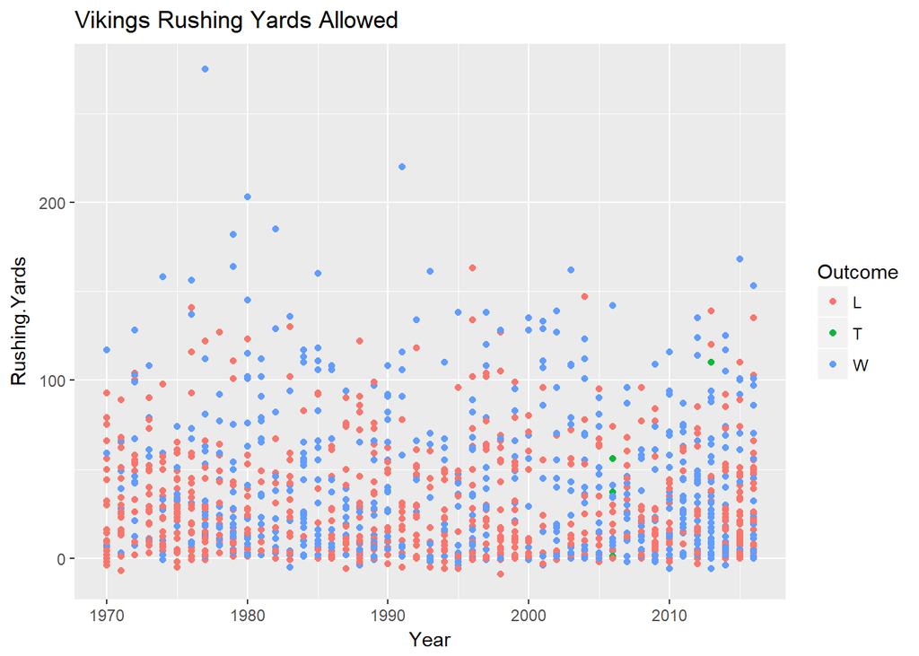

```r
filtered_rb_df %>%
  ggplot(aes(x=`Year`, y=`Rushing.Yards`)) +
  geom_point(mapping=aes(color=`Outcome`)) +
  labs(title = "Vikings Rushing Yards Allowed")
```

A similarly surprising analysis to the passing yards plot could be made for the rushing yards plot.

So we know that there probably isn’t a strong correlation between winning (or losing) and yards allowed for the Vikings defense due to the lack of observable patterns in the previous two plots.

But how do they compare to the rest of the league?

# Analyzing

Lets look at passing stats specifically first. Lets wrangle our original data in a different way, with mostly the same criteria, but this looking at all of the possible opponents to get data from the whole league. Then we will take that league passing data and use the ggplot library to look at the average passing yardage per year for the entire league.

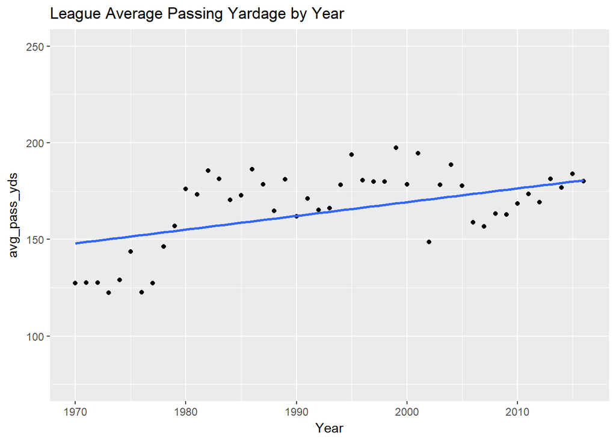

```r
league_qb_stats_tab <- qb_stats_tab %>%
  filter(`Year` >= 1950) %>%
  filter(`Passes Attempted` >= 1) %>%
  transform(`Passing Yards` = as.numeric(`Passing Yards`)) %>%
  group_by(`Year`) %>%
  mutate(avg_pass_yds = mean(`Passing.Yards`))

league_qb_stats_tab %>%
  ggplot(aes(x=`Year`, y=`avg_pass_yds`)) +
  geom_point() +
  geom_smooth(method=lm) +
  labs(title="League Average Passing Yardage by Year") +
  ylim(75,250)
```

We then want to plot the average passing yards allowed by the Vikings’ defense in order to make a comparison:

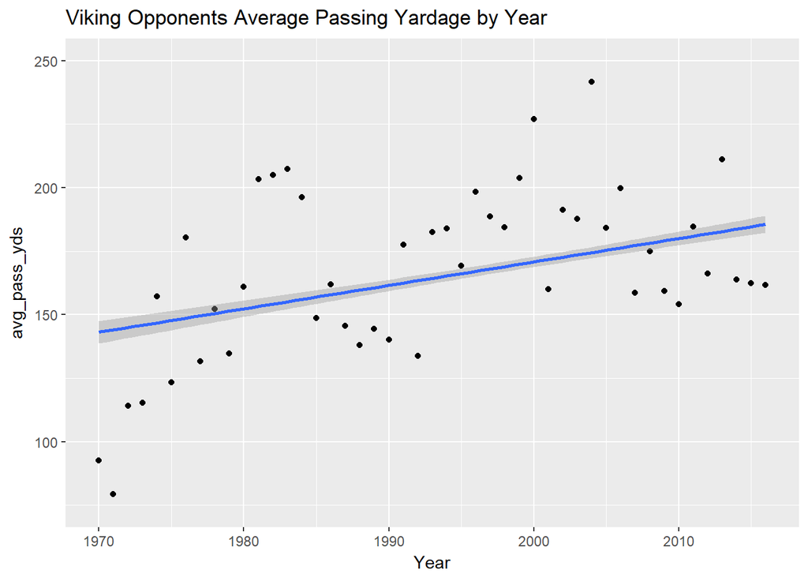

```r
filtered_qb_df %>%
  ggplot(aes(x=`Year`, y=`avg_pass_yds`, se=FALSE)) +
  geom_point() +
  geom_smooth(method=lm) +
  labs(title="Viking Opponents Average Passing Yardage by Year") +
  ylim(75,250)
```

The slopes of the regression lines drawn by geom_smooth appear to relatively similar to each other. (only 0.2 different) This means that the trend of the Vikings’ defense isn’t very different than that of the the whole league, in fact, it is slightly worse.

Let’s do the same thing for average rushing yardage of the league:

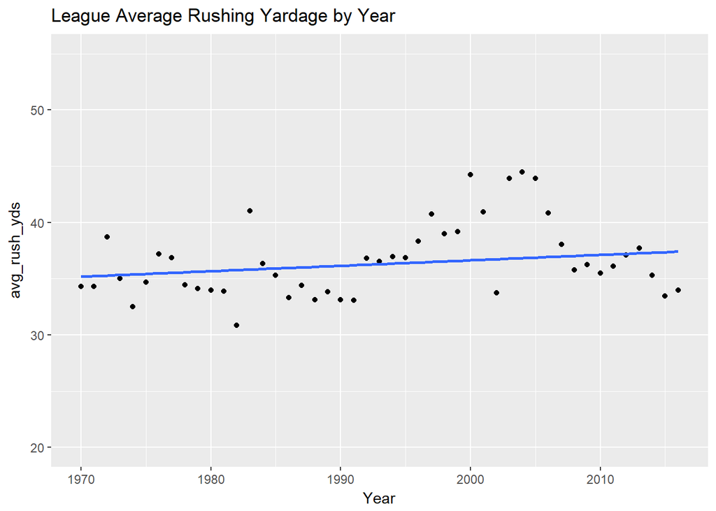

```r
league_rb_stats_tab <- rb_stats_tab %>%
  filter(`Year` >= 1950) %>%
  filter(`Rushing Attempts` >= 1) %>%
  transform(`Rushing Yards` = as.numeric(`Rushing Yards`)) %>%
  group_by(`Year`) %>%
  mutate(avg_rush_yds = mean(`Rushing.Yards`))

league_rb_stats_tab %>%
  ggplot(aes(x=`Year`, y=`avg_rush_yds`)) +
  geom_point() +
  geom_smooth(method=lm) +
  labs(title="League Average Rushing Yardage by Year") +
  ylim(20,55)
```

And repeat in a similar fashion to get average Viking rush yardage allowed:

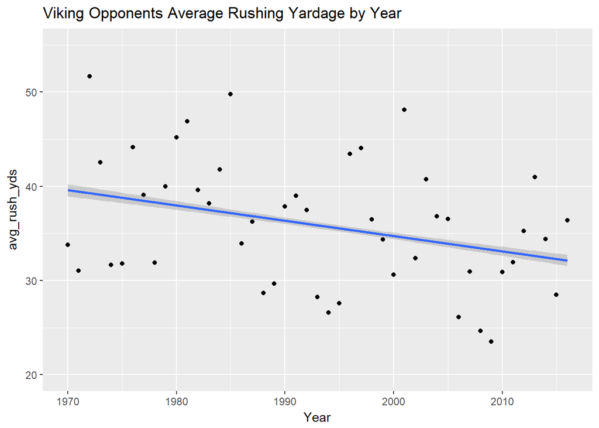

```r
filtered_rb_df %>%
  ggplot(aes(x=`Year`, y=`avg_rush_yds`)) +
  geom_point() +
  geom_smooth(method=lm) +
  labs(title="Viking Opponents Average Rushing Yardage by Year") +
  ylim(20, 55)
```

Finally, we see a difference between the league averages and Minnesota’s trend. The league has gradually increased in its average rush yardage allowed over the last 40 years, but the Vikings actually have a downward trend, albeit mild.

So what does this mean?

# Hypothesis Testing

The hypothesis is that the proposed regressions are models that fit the data well. (Also called Lack-of-fit sum of squares) We want to see if our linear analysis of this data is valid. (And if it could potentially be used to predict future behavior)

We actually already did all of the analysis that we needed while finding the slopes

```r
league_passyds_fit <- lm(avg_pass_yds~Year, data=league_qb_stats_tab)
broom::tidy(league_passyds_fit)
```

```
##          term      estimate    std.error statistic p.value
## 1 (Intercept) -1250.3163623 15.109365895 -82.75108       0
## 2        Year     0.7097944  0.007562016  93.86313       0
```

### Viking Average Pass Yards

```r
viking_passyds_fit <- lm(avg_pass_yds~Year, data=filtered_qb_df)
broom::tidy(viking_passyds_fit)
```

```
##          term      estimate    std.error statistic      p.value
## 1 (Intercept) -1673.8064867 148.18128245 -11.29567 2.676534e-27
## 2        Year     0.9222781   0.07418868  12.43152 3.320617e-32
```

### League Average Rush Yards

```r
league_rushyds_fit <- lm(avg_rush_yds~Year, data=league_rb_stats_tab)
broom::tidy(league_rushyds_fit)
```

```
##          term     estimate  std.error statistic       p.value
## 1 (Intercept) -60.09257191 2.09195253 -28.72559 1.234095e-179
## 2        Year   0.04836286 0.00104827  46.13590  0.000000e+00
```

### Viking Average Rush Yards

```r
viking_rushyds_fit <- lm(avg_rush_yds~Year, data=filtered_rb_df)
broom::tidy(viking_rushyds_fit)
```

```
##          term    estimate   std.error statistic      p.value
## 1 (Intercept) 358.4813996 23.20447447  15.44880 1.143312e-49
## 2        Year  -0.1618749  0.01163311 -13.91501 3.289900e-41
```

From these tables, you can pull the Y-intercept and Slope of the linear model from the estimate column of the (Intercept) and Year terms, respectively. (Keep in mind that the Y-intercept doesn’t mean much functionally, because the data only goes back to 1970)

More important for our analysis are the p-values in the last column. These indicate a statistical significance that could not occur due to randomness. If a p-value is lower than the confidence interval of p = 0.05, than it is safe to reject the Null Hypothesis. In this case, the Null Hypothesis is that there is no difference between a random distribution and our data.

Because all 4 of the p-values are much lower than the given confidence interval, we can say that the linear models we found do accurately reflect a general trend in the data we have.

# Final Analysis